# Contract Breach Size

### Model 04B: Undefinitized Contract Awards

Undefinitized Contract Awards allow for quick action in situations where there is not time or information to establish all of a contracts properties at the time of signing. They have been found by the GAO and the Performance of the Defense Acquisition studies to contain notable risks, primarily relating to cost overruns and thus ceiling breaches. Will these risks also carry into terminations and ceiling breaches?

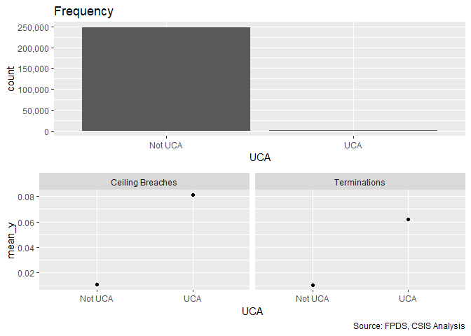

```
## [[1]]
##
## Not UCA     UCA
##  248794    1206
##
## [[2]]
##
##             None Ceiling Breach
##   Not UCA 246017           2777
##   UCA       1108             98
##
## [[3]]
##
##                0      1
##   Not UCA 246241   2553
##   UCA       1131     75
```

```r
#Frequency Plot
summary_discrete_plot(smp,"UCA")
```

```r
#Create the model
ln_CBre_04B <- glm (data=smp,
                 ln_CBre_Then_Year ~ b_UCA )
summary(ln_CBre_04B)
```

```
##
## Call:
## glm(formula = ln_CBre_Then_Year ~ b_UCA, data = smp)
##
## Deviance Residuals:
##     Min       1Q   Median       3Q      Max
## -0.8239  -0.1014  -0.1014  -0.1014  19.4159
##
## Coefficients:
##             Estimate Std. Error t value Pr(>|t|)
## (Intercept) 0.101380   0.002033   49.87   <2e-16 ***
## b_UCA       0.722559   0.029269   24.69   <2e-16 ***
## ---
## Signif. codes:  0 '***' 0.001 '**' 0.01 '*' 0.05 '.' 0.1 ' ' 1
##
## (Dispersion parameter for gaussian family taken to be 1.028198)
##
##     Null deviance: 257674  on 249999  degrees of freedom
## Residual deviance: 257048  on 249998  degrees of freedom
## AIC: 716425
##
## Number of Fisher Scoring iterations: 2
```

```r
stargazer::stargazer(ln_CBre_04A,ln_CBre_04B,ln_CBre_Cons_NCS6A,ln_CBre_Cons_NCS3A,ln_CBre_Cons_03B,
                       ln_CBre_Comp_01A,ln_CBre_Comp_03B,type="text",
                       digits=2)
```

```
##
## ==================================================================================================================
##                                                                Dependent variable:
##                                -----------------------------------------------------------------------------------
##                                                                 ln_CBre_Then_Year
##                                    (1)         (2)         (3)         (4)         (5)         (6)         (7)
## ------------------------------------------------------------------------------------------------------------------
## PricingFeeOther FP              -0.10***
##                                  (0.01)
##
## PricingFeeIncentive              0.12***
##                                  (0.03)
##
## PricingFeeCombination or Other   0.36***
##                                  (0.03)
##
## PricingFeeOther CB               0.31***
##                                  (0.02)
##
## PricingFeeT&M/LH/FPLOE            0.02
##                                  (0.02)
##
## b_UCA                                        0.72***
##                                              (0.03)
##
## cl_def6_HHI_lag1                                        -0.10***                -0.03***
##                                                          (0.004)                 (0.01)
##
## cl_def6_ratio_lag1                                                               -0.004                  -0.01**
##                                                                                  (0.005)                 (0.005)
##
## cl_def6_obl_lag1                                                                 0.05***                 0.05***
##                                                                                  (0.01)                  (0.01)
##
## cl_US6_avg_sal_lag1                                                             -0.03***                -0.04***
##                                                                                  (0.005)                 (0.005)
##
## cl_def3_HHI_lag1                                                    -0.16***    -0.05***
##                                                                      (0.004)     (0.01)
##
```

[output cut: 27 more lines]

```
## CompOffr3-4 offers                                                                          -0.04***     -0.01*
##                                                                                              (0.01)      (0.01)
##
## CompOffr5+ offers                                                                           -0.07***    -0.03***
##                                                                                              (0.01)      (0.01)
##
## Constant                         0.11***     0.10***     0.10***     0.10***    -0.50***     0.16***    -0.47***
##                                  (0.002)     (0.002)     (0.002)     (0.002)     (0.01)      (0.005)     (0.01)
##
## ------------------------------------------------------------------------------------------------------------------
## Observations                     250,000     250,000     250,000     250,000     250,000     250,000     250,000
## Log Likelihood                 -358,180.60 -358,210.60 -358,187.00 -357,791.30 -355,752.90 -358,404.30 -355,824.70
## Akaike Inf. Crit.              716,373.20  716,425.30  716,378.00  715,586.70  711,531.90  716,818.60  711,679.40
## ==================================================================================================================
## Note:                                                                                  *p<0.1; **p<0.05; ***p<0.01
```

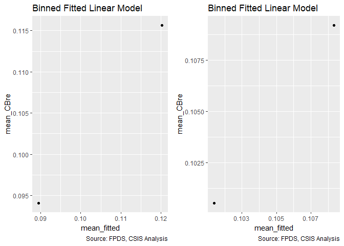

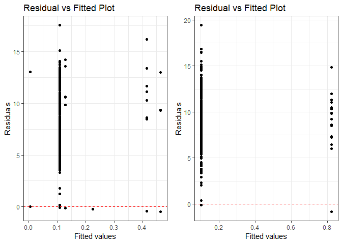

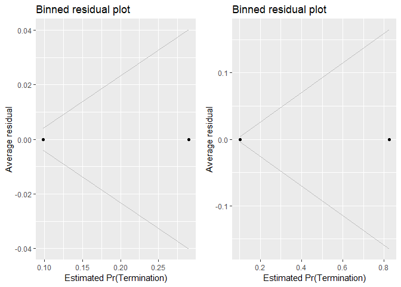

```r
#Compare to earlier contract types
summary_residual_compare(ln_CBre_04A,ln_CBre_04B,bins=2,skip_vif = TRUE)
```

UCAs are associated with more/larger ceiling breaches ,as expected.

### Model 04C: Cumulative

```r
#Create the model
ln_CBre_Cons_04C <- glm (data=smp,
                 ln_CBre_Then_Year ~cl_def6_HHI_lag1+cl_def6_ratio_lag1+cl_def6_obl_lag1+cl_US6_avg_sal_lag1+
                   cl_def3_HHI_lag1+cl_def3_ratio_lag1+
                   cl_Ceil_Then_Year+ cl_Days+
                   Veh+
                   PricingFee+b_UCA)
glmer_examine(ln_CBre_Cons_04C)
```

```
##                         GVIF Df GVIF^(1/(2*Df))
## cl_def6_HHI_lag1    1.856415  1        1.362503
## cl_def6_ratio_lag1  1.607797  1        1.267990
## cl_def6_obl_lag1    1.912171  1        1.382813
## cl_US6_avg_sal_lag1 1.513374  1        1.230193
## cl_def3_HHI_lag1    1.818926  1        1.348676
## cl_def3_ratio_lag1  1.905150  1        1.380272
## cl_Ceil_Then_Year   1.385423  1        1.177040
## cl_Days             1.761279  1        1.327132
## Veh                 1.838251  4        1.079072
## PricingFee          1.451896  5        1.037991
## b_UCA               1.008847  1        1.004414
```

```r
ln_CBre_Comp_04C <- glm (data=smp,
                 ln_CBre_Then_Year ~CompOffr+
                   cl_def6_ratio_lag1+cl_def6_obl_lag1+cl_US6_avg_sal_lag1+
                   cl_def3_ratio_lag1+
                   cl_Ceil_Then_Year+ cl_Days+
                   Veh+
                   PricingFee+b_UCA)
glmer_examine(ln_CBre_Comp_04C)
```

```
##                         GVIF Df GVIF^(1/(2*Df))
## CompOffr            1.251779  4        1.028468
## cl_def6_ratio_lag1  1.596545  1        1.263545
## cl_def6_obl_lag1    1.937423  1        1.391913
## cl_US6_avg_sal_lag1 1.473122  1        1.213722
## cl_def3_ratio_lag1  1.953839  1        1.397798
## cl_Ceil_Then_Year   1.369005  1        1.170045
## cl_Days             1.626391  1        1.275300
## Veh                 1.756041  4        1.072919
## PricingFee          1.402291  5        1.034389
## b_UCA               1.013654  1        1.006804
```

```r
stargazer::stargazer(ln_CBre_04A,ln_CBre_04B,ln_CBre_Cons_NCS6A,ln_CBre_Cons_NCS3A,ln_CBre_Cons_03B,ln_CBre_Cons_04C,
                       ln_CBre_Comp_01A,ln_CBre_Comp_03B,ln_CBre_Comp_04C,type="text",
                       digits=2)
```

```
##
## ==========================================================================================================================================
##                                                                            Dependent variable:
##                                -----------------------------------------------------------------------------------------------------------
##                                                                             ln_CBre_Then_Year
##                                    (1)         (2)         (3)         (4)         (5)         (6)         (7)         (8)         (9)
## ------------------------------------------------------------------------------------------------------------------------------------------
## PricingFeeOther FP              -0.10***                                                      0.01                               0.02**
##                                  (0.01)                                                      (0.01)                              (0.01)
##
## PricingFeeIncentive              0.12***                                                      0.05                                0.05
##                                  (0.03)                                                      (0.03)                              (0.03)
##
## PricingFeeCombination or Other   0.36***                                                     0.19***                             0.20***
##                                  (0.03)                                                      (0.03)                              (0.03)
##
## PricingFeeOther CB               0.31***                                                     -0.004                               0.03
##                                  (0.02)                                                      (0.02)                              (0.02)
##
## PricingFeeT&M/LH/FPLOE            0.02                                                      -0.07***                            -0.06***
##                                  (0.02)                                                      (0.02)                              (0.02)
##
## b_UCA                                        0.72***                                         0.58***                             0.58***
##                                              (0.03)                                          (0.03)                              (0.03)
##
## cl_def6_HHI_lag1                                        -0.10***                -0.03***    -0.02***
##                                                          (0.004)                 (0.01)      (0.01)
##
## cl_def6_ratio_lag1                                                               -0.004      -0.003                  -0.01**     -0.01*
##                                                                                  (0.005)     (0.005)                 (0.005)     (0.005)
##
## cl_def6_obl_lag1                                                                 0.05***     0.05***                 0.05***     0.05***
##                                                                                  (0.01)      (0.01)                  (0.01)      (0.01)
##
## cl_US6_avg_sal_lag1                                                             -0.03***    -0.03***                -0.04***    -0.04***
##                                                                                  (0.005)     (0.005)                 (0.005)     (0.005)
##
## cl_def3_HHI_lag1                                                    -0.16***    -0.05***    -0.05***
##                                                                      (0.004)     (0.01)      (0.01)
##
```

[output cut: 27 more lines]

```
## CompOffr3-4 offers                                                                                      -0.04***     -0.01*       -0.01
##                                                                                                          (0.01)      (0.01)      (0.01)
##
## CompOffr5+ offers                                                                                       -0.07***    -0.03***    -0.02***
##                                                                                                          (0.01)      (0.01)      (0.01)
##
## Constant                         0.11***     0.10***     0.10***     0.10***    -0.50***    -0.50***     0.16***    -0.47***    -0.48***
##                                  (0.002)     (0.002)     (0.002)     (0.002)     (0.01)      (0.01)      (0.005)     (0.01)      (0.02)
##
## ------------------------------------------------------------------------------------------------------------------------------------------
## Observations                     250,000     250,000     250,000     250,000     250,000     250,000     250,000     250,000     250,000
## Log Likelihood                 -358,180.60 -358,210.60 -358,187.00 -357,791.30 -355,752.90 -355,525.50 -358,404.30 -355,824.70 -355,597.20
## Akaike Inf. Crit.              716,373.20  716,425.30  716,378.00  715,586.70  711,531.90  711,089.00  716,818.60  711,679.40  711,236.30
## ==========================================================================================================================================
## Note:                                                                                                          *p<0.1; **p<0.05; ***p<0.01
```

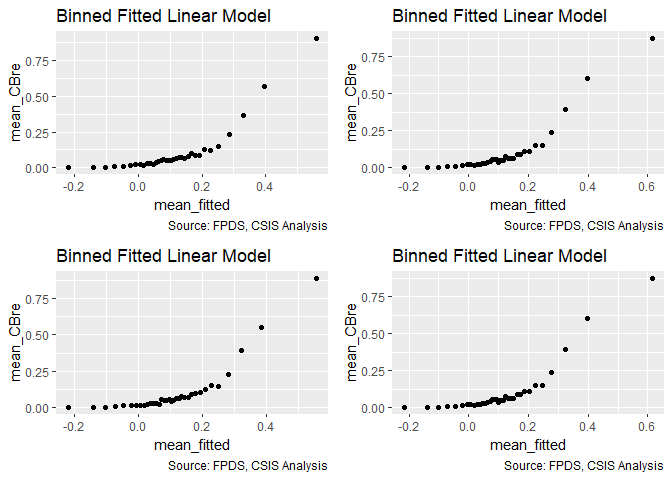

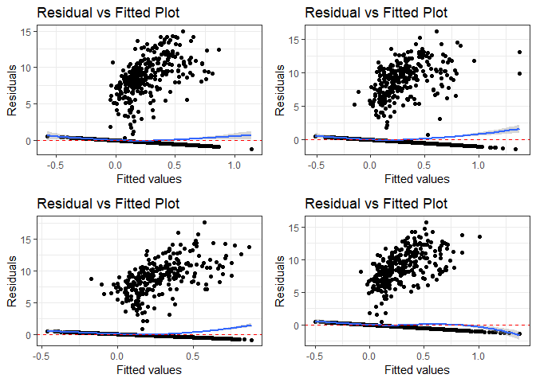

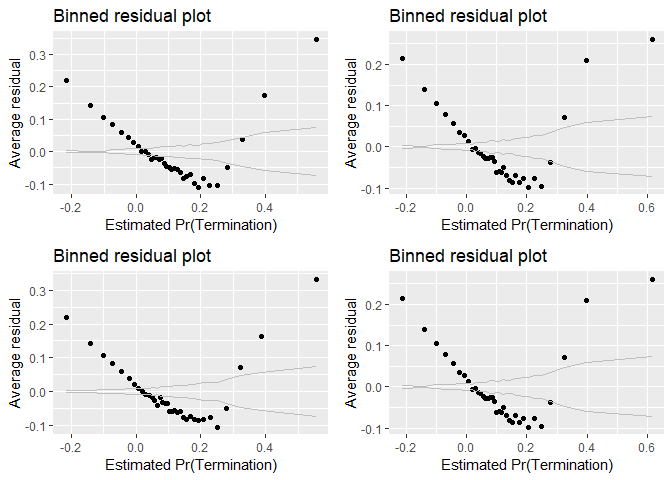

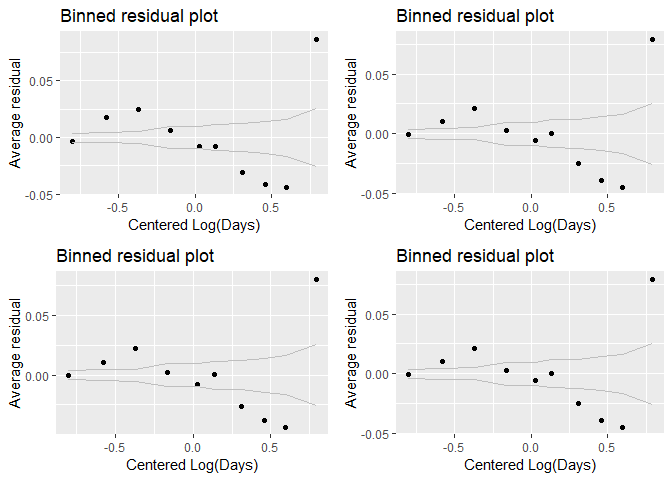

```r
#Compare with cumulative consolidation and competition
summary_residual_compare(ln_CBre_Cons_03B,ln_CBre_Comp_04C,ln_CBre_Comp_03B,ln_CBre_Comp_04C,bins=20,skip_vif = TRUE)
```

```r
rm(ln_CBre_04A,ln_CBre_04B)

if(exists("ln_CBre_03A")) rm(ln_CBre_03A)
```

The pricing variables reduce significance for HHI and magnitude for Comp. Changes for vehicle are more sporatic. Def3_ratio and ceiling also face decreasing/loss of significance. UCA and Combination/Fee have perhaps the largest coefficients.

## Place of Performance

### Model 05A: Any International

International contracts may often be in conflict zones and thus experience greater risk. International contracts are exepected to estimate a higher probability of ceiling breaches.

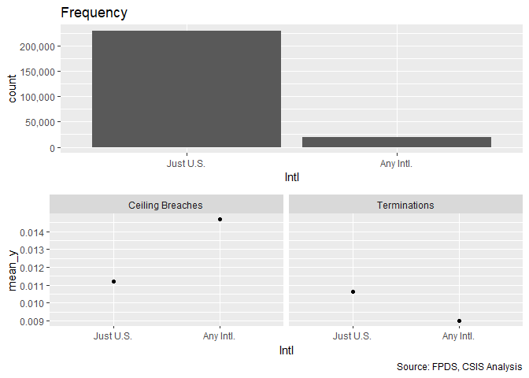

```
## [[1]]
##
## Just U.S. Any Intl.
##    229984     20016
##
## [[2]]
##
##               None Ceiling Breach
##   Just U.S. 227403           2581
##   Any Intl.  19722            294
##
## [[3]]
##
##                  0      1
##   Just U.S. 227536   2448
##   Any Intl.  19836    180
```

```r
#Frequency Plot
summary_discrete_plot(smp,"Intl")
```

```r
#Create the model
ln_CBre_05A <- glm(data=smp,
  ln_CBre_Then_Year ~b_Intl
)
summary(ln_CBre_05A)
```

```
##
## Call:
## glm(formula = ln_CBre_Then_Year ~ b_Intl, data = smp)
##
## Deviance Residuals:
##     Min       1Q   Median       3Q      Max
## -0.1327  -0.1024  -0.1024  -0.1024  19.4148
##
## Coefficients:
##             Estimate Std. Error t value Pr(>|t|)
## (Intercept) 0.102439   0.002117   48.39  < 2e-16 ***
## b_Intl      0.030301   0.007481    4.05 5.12e-05 ***
## ---
## Signif. codes:  0 '***' 0.001 '**' 0.01 '*' 0.05 '.' 0.1 ' ' 1
##
## (Dispersion parameter for gaussian family taken to be 1.030637)
##
##     Null deviance: 257674  on 249999  degrees of freedom
## Residual deviance: 257657  on 249998  degrees of freedom
## AIC: 717018
##
## Number of Fisher Scoring iterations: 2
```

```r
stargazer::stargazer(ln_CBre_05A,ln_CBre_Cons_NCS6A,ln_CBre_Cons_NCS3A,ln_CBre_Cons_04C,
                       ln_CBre_Comp_01A,ln_CBre_Comp_04C,type="text",
                       digits=2)
```

```
##
## ======================================================================================================
##                                                          Dependent variable:
##                                -----------------------------------------------------------------------
##                                                           ln_CBre_Then_Year
##                                    (1)         (2)         (3)         (4)         (5)         (6)
## ------------------------------------------------------------------------------------------------------
## b_Intl                           0.03***
##                                  (0.01)
##
## cl_def6_HHI_lag1                            -0.10***                -0.02***
##                                              (0.004)                 (0.01)
##
## cl_def6_ratio_lag1                                                   -0.003                  -0.01*
##                                                                      (0.005)                 (0.005)
##
## cl_def6_obl_lag1                                                     0.05***                 0.05***
##                                                                      (0.01)                  (0.01)
##
## cl_US6_avg_sal_lag1                                                 -0.03***                -0.04***
##                                                                      (0.005)                 (0.005)
##
## cl_def3_HHI_lag1                                        -0.16***    -0.05***
##                                                          (0.004)     (0.01)
##
## cl_def3_ratio_lag1                                                  -0.04***                -0.04***
##                                                                      (0.01)                  (0.01)
##
## cl_Ceil_Then_Year                                                    1.21***                 1.23***
##                                                                      (0.03)                  (0.03)
##
## cl_Days                                                              0.10***                 0.11***
##                                                                      (0.01)                  (0.01)
##
## VehS-IDC                                                             0.05***                 0.03***
##                                                                      (0.01)                  (0.01)
##
## VehM-IDC                                                             0.28***                 0.28***
##                                                                      (0.01)                  (0.01)
##
```

[output cut: 30 more lines]

```
## CompOffr3-4 offers                                                              -0.04***      -0.01
##                                                                                  (0.01)      (0.01)
##
## CompOffr5+ offers                                                               -0.07***    -0.02***
##                                                                                  (0.01)      (0.01)
##
## Constant                         0.10***     0.10***     0.10***    -0.50***     0.16***    -0.48***
##                                  (0.002)     (0.002)     (0.002)     (0.01)      (0.005)     (0.02)
##
## ------------------------------------------------------------------------------------------------------
## Observations                     250,000     250,000     250,000     250,000     250,000     250,000
## Log Likelihood                 -358,506.80 -358,187.00 -357,791.30 -355,525.50 -358,404.30 -355,597.20
## Akaike Inf. Crit.              717,017.60  716,378.00  715,586.70  711,089.00  716,818.60  711,236.30
## ======================================================================================================
## Note:                                                                      *p<0.1; **p<0.05; ***p<0.01
```

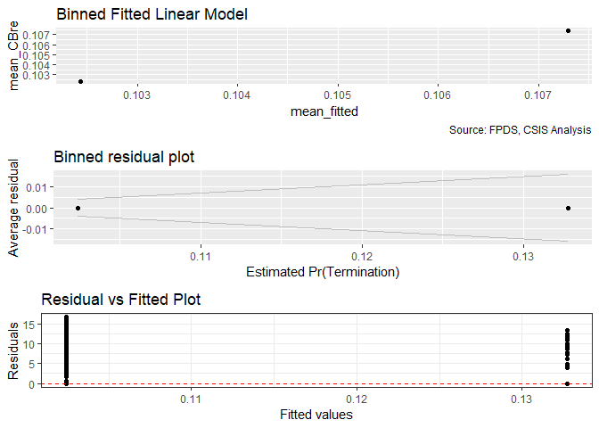

```r
#For first model in category, include only the new model(s), skip_vif=true
summary_residual_compare(ln_CBre_05A,bins=2,skip_vif = TRUE)
```

International performance of contract had a positive coefficent as expected.

### Model 05B: Cumulative

```r
#Create the model
ln_CBre_Cons_05B <- glm (data=smp,
                 ln_CBre_Then_Year ~cl_def6_HHI_lag1+cl_def6_ratio_lag1+cl_def6_obl_lag1+cl_US6_avg_sal_lag1+
                   cl_def3_HHI_lag1+cl_def3_ratio_lag1+
                   cl_Ceil_Then_Year+ cl_Days+
                   Veh+
                   PricingFee+b_UCA+
                   b_Intl)
glmer_examine(ln_CBre_Cons_05B)
```

```
##                         GVIF Df GVIF^(1/(2*Df))
## cl_def6_HHI_lag1    1.876019  1        1.369678
## cl_def6_ratio_lag1  1.608556  1        1.268288
## cl_def6_obl_lag1    1.938005  1        1.392122
## cl_US6_avg_sal_lag1 1.559415  1        1.248765
## cl_def3_HHI_lag1    1.819463  1        1.348875
## cl_def3_ratio_lag1  1.910972  1        1.382379
## cl_Ceil_Then_Year   1.400351  1        1.183364
## cl_Days             1.762184  1        1.327473
## Veh                 1.851395  4        1.080034
## PricingFee          1.455717  5        1.038264
## b_UCA               1.009141  1        1.004560
## b_Intl              1.074978  1        1.036811
```

```r
ln_CBre_Comp_05B <- glm (data=smp,
                 ln_CBre_Then_Year ~CompOffr+
                   cl_def6_ratio_lag1+cl_def6_obl_lag1+cl_US6_avg_sal_lag1+
                   cl_def3_ratio_lag1+
                   cl_Ceil_Then_Year+ cl_Days+
                   Veh+
                   PricingFee+b_UCA+
                   b_Intl)
glmer_examine(ln_CBre_Comp_05B)
```

```
##                         GVIF Df GVIF^(1/(2*Df))
## CompOffr            1.272327  4        1.030564
## cl_def6_ratio_lag1  1.596791  1        1.263642
## cl_def6_obl_lag1    1.963448  1        1.401231
## cl_US6_avg_sal_lag1 1.503402  1        1.226133
## cl_def3_ratio_lag1  1.960893  1        1.400319
## cl_Ceil_Then_Year   1.386077  1        1.177318
## cl_Days             1.632585  1        1.277727
## Veh                 1.769298  4        1.073928
## PricingFee          1.407768  5        1.034792
## b_UCA               1.013845  1        1.006899
## b_Intl              1.075056  1        1.036849
```

```r
stargazer::stargazer(ln_CBre_05A,ln_CBre_Cons_NCS6A,ln_CBre_Cons_NCS3A,ln_CBre_Cons_04C,ln_CBre_Cons_05B,
                       ln_CBre_Comp_01A,ln_CBre_Comp_04C,ln_CBre_Comp_05B,type="text",
                       digits=2)
```

```
##
## ==============================================================================================================================
##                                                                      Dependent variable:
##                                -----------------------------------------------------------------------------------------------
##                                                                       ln_CBre_Then_Year
##                                    (1)         (2)         (3)         (4)         (5)         (6)         (7)         (8)
## ------------------------------------------------------------------------------------------------------------------------------
## b_Intl                           0.03***                                          -0.01                              -0.01*
##                                  (0.01)                                          (0.01)                              (0.01)
##
## cl_def6_HHI_lag1                            -0.10***                -0.02***    -0.02***
##                                              (0.004)                 (0.01)      (0.01)
##
## cl_def6_ratio_lag1                                                   -0.003      -0.003                  -0.01*      -0.01*
##                                                                      (0.005)     (0.005)                 (0.005)     (0.005)
##
## cl_def6_obl_lag1                                                     0.05***     0.05***                 0.05***     0.05***
##                                                                      (0.01)      (0.01)                  (0.01)      (0.01)
##
## cl_US6_avg_sal_lag1                                                 -0.03***    -0.03***                -0.04***    -0.04***
##                                                                      (0.005)     (0.01)                  (0.005)     (0.005)
##
## cl_def3_HHI_lag1                                        -0.16***    -0.05***    -0.05***
##                                                          (0.004)     (0.01)      (0.01)
##
## cl_def3_ratio_lag1                                                  -0.04***    -0.04***                -0.04***    -0.04***
##                                                                      (0.01)      (0.01)                  (0.01)      (0.01)
##
## cl_Ceil_Then_Year                                                    1.21***     1.21***                 1.23***     1.24***
##                                                                      (0.03)      (0.03)                  (0.03)      (0.03)
##
## cl_Days                                                              0.10***     0.10***                 0.11***     0.11***
##                                                                      (0.01)      (0.01)                  (0.01)      (0.01)
##
## VehS-IDC                                                             0.05***     0.05***                 0.03***     0.03***
##                                                                      (0.01)      (0.01)                  (0.01)      (0.01)
##
## VehM-IDC                                                             0.28***     0.28***                 0.28***     0.28***
##                                                                      (0.01)      (0.01)                  (0.01)      (0.01)
##
```

[output cut: 30 more lines]

```
## CompOffr3-4 offers                                                                          -0.04***      -0.01      -0.004
##                                                                                              (0.01)      (0.01)      (0.01)
##
## CompOffr5+ offers                                                                           -0.07***    -0.02***    -0.02***
##                                                                                              (0.01)      (0.01)      (0.01)
##
## Constant                         0.10***     0.10***     0.10***    -0.50***    -0.50***     0.16***    -0.48***    -0.48***
##                                  (0.002)     (0.002)     (0.002)     (0.01)      (0.01)      (0.005)     (0.02)      (0.02)
##
## ------------------------------------------------------------------------------------------------------------------------------
## Observations                     250,000     250,000     250,000     250,000     250,000     250,000     250,000     250,000
## Log Likelihood                 -358,506.80 -358,187.00 -357,791.30 -355,525.50 -355,525.20 -358,404.30 -355,597.20 -355,595.50
## Akaike Inf. Crit.              717,017.60  716,378.00  715,586.70  711,089.00  711,090.40  716,818.60  711,236.30  711,235.00
## ==============================================================================================================================
## Note:                                                                                              *p<0.1; **p<0.05; ***p<0.01
```

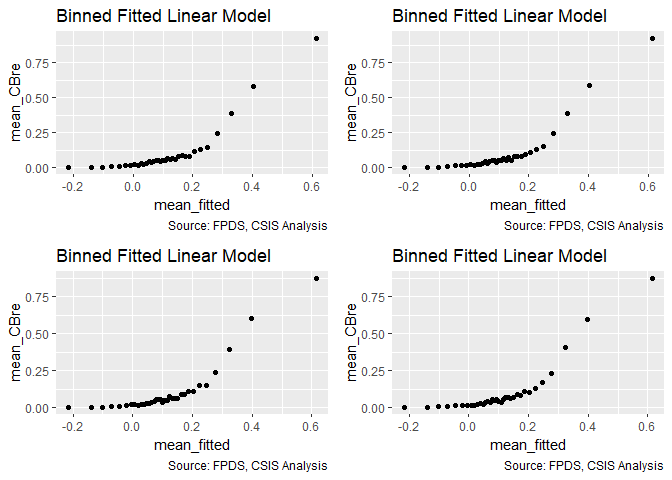

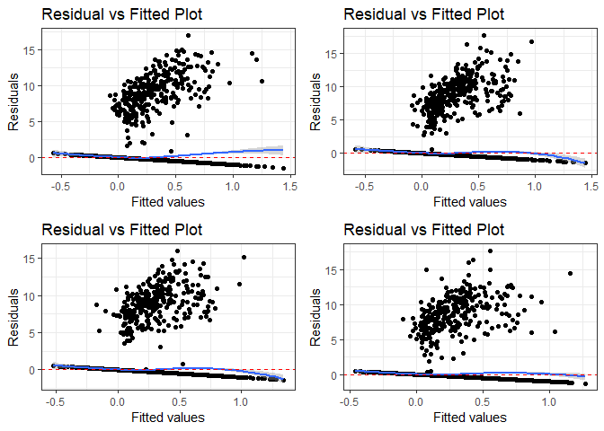

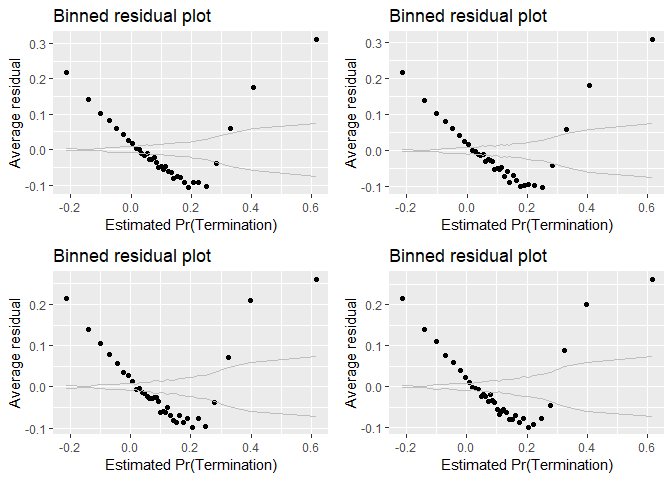

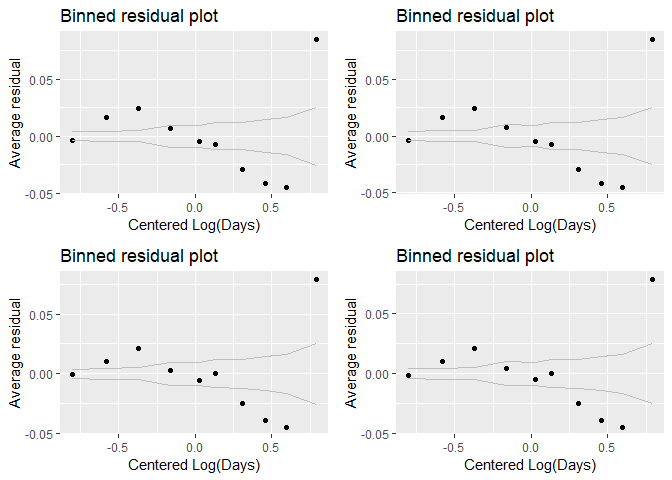

```
## [[1]]
##        model deviance null.deviance difference
## 1 model1_old 251584.7      257674.1   6089.379
## 2 model1_new 251584.1      257674.1   6090.007
## 3 model2_old 251729.0      257674.1   5945.136
## 4 model2_new 251725.7      257674.1   5948.418
##
## [[2]]
##                         GVIF Df GVIF^(1/(2*Df))
## cl_def6_HHI_lag1    1.876019  1        1.369678
## cl_def6_ratio_lag1  1.608556  1        1.268288
## cl_def6_obl_lag1    1.938005  1        1.392122
## cl_US6_avg_sal_lag1 1.559415  1        1.248765
## cl_def3_HHI_lag1    1.819463  1        1.348875
## cl_def3_ratio_lag1  1.910972  1        1.382379
## cl_Ceil_Then_Year   1.400351  1        1.183364
## cl_Days             1.762184  1        1.327473
## Veh                 1.851395  4        1.080034
## PricingFee          1.455717  5        1.038264
## b_UCA               1.009141  1        1.004560
## b_Intl              1.074978  1        1.036811
##
## [[3]]
##                         GVIF Df GVIF^(1/(2*Df))
## CompOffr            1.272327  4        1.030564
## cl_def6_ratio_lag1  1.596791  1        1.263642
## cl_def6_obl_lag1    1.963448  1        1.401231
## cl_US6_avg_sal_lag1 1.503402  1        1.226133
## cl_def3_ratio_lag1  1.960893  1        1.400319
## cl_Ceil_Then_Year   1.386077  1        1.177318
## cl_Days             1.632585  1        1.277727
## Veh                 1.769298  4        1.073928
## PricingFee          1.407768  5        1.034792
## b_UCA               1.013845  1        1.006899
## b_Intl              1.075056  1        1.036849
```

```r
#ompare with cumulative consolidation and competition
summary_residual_compare(ln_CBre_Cons_04C,ln_CBre_Cons_05B,ln_CBre_Comp_04C,ln_CBre_Comp_05B,bins=20,skip_vif = FALSE)
```

```r
rm(ln_CBre_05A)

if(exists("ln_CBre_04A")) rm(ln_CBre_04A,ln_CBre_04B)
```

## Competition and Consolidation together

### Model 09A: Combination

```r
#Sumamry plot

ln_CBre_Cons_Comp_09A <- glm (data=smp,
                 ln_CBre_Then_Year ~CompOffr+cl_def6_HHI_lag1+cl_def6_ratio_lag1+cl_def6_obl_lag1+cl_US6_avg_sal_lag1+
                   cl_def3_HHI_lag1+cl_def3_ratio_lag1+
                   cl_Ceil_Then_Year+ cl_Days+
                   Veh+
                   PricingFee+b_UCA+
                   b_Intl)
glmer_examine(ln_CBre_Cons_Comp_09A)
```

```
##                         GVIF Df GVIF^(1/(2*Df))
## CompOffr            1.293347  4        1.032677
## cl_def6_HHI_lag1    1.881330  1        1.371616
## cl_def6_ratio_lag1  1.610627  1        1.269105
## cl_def6_obl_lag1    1.976662  1        1.405938
## cl_US6_avg_sal_lag1 1.570569  1        1.253223
## cl_def3_HHI_lag1    1.834207  1        1.354329
## cl_def3_ratio_lag1  1.963988  1        1.401423
## cl_Ceil_Then_Year   1.416627  1        1.190221
## cl_Days             1.770556  1        1.330623
## Veh                 1.905690  4        1.083943
## PricingFee          1.511523  5        1.042177
## b_UCA               1.014033  1        1.006992
## b_Intl              1.093142  1        1.045534
```

```r
stargazer::stargazer(ln_CBre_Cons_NCS6A,ln_CBre_Cons_NCS3A,ln_CBre_Cons_05B,
                       ln_CBre_Comp_01A,ln_CBre_Comp_05B,ln_CBre_Cons_Comp_09A,type="text",
                       digits=2)
```

```
##
## ======================================================================================================
##                                                          Dependent variable:
##                                -----------------------------------------------------------------------
##                                                           ln_CBre_Then_Year
##                                    (1)         (2)         (3)         (4)         (5)         (6)
## ------------------------------------------------------------------------------------------------------
## cl_def6_HHI_lag1                -0.10***                -0.02***                            -0.02***
##                                  (0.004)                 (0.01)                              (0.01)
##
## cl_def6_ratio_lag1                                       -0.003                  -0.01*      -0.003
##                                                          (0.005)                 (0.005)     (0.005)
##
## cl_def6_obl_lag1                                         0.05***                 0.05***     0.05***
##                                                          (0.01)                  (0.01)      (0.01)
##
## cl_US6_avg_sal_lag1                                     -0.03***                -0.04***    -0.03***
##                                                          (0.01)                  (0.005)     (0.01)
##
## cl_def3_HHI_lag1                            -0.16***    -0.05***                            -0.05***
##                                              (0.004)     (0.01)                              (0.01)
##
## cl_def3_ratio_lag1                                      -0.04***                -0.04***    -0.04***
##                                                          (0.01)                  (0.01)      (0.01)
##
## cl_Ceil_Then_Year                                        1.21***                 1.24***     1.20***
##                                                          (0.03)                  (0.03)      (0.03)
##
## cl_Days                                                  0.10***                 0.11***     0.09***
##                                                          (0.01)                  (0.01)      (0.01)
##
## VehS-IDC                                                 0.05***                 0.03***     0.05***
##                                                          (0.01)                  (0.01)      (0.01)
##
## VehM-IDC                                                 0.28***                 0.28***     0.28***
##                                                          (0.01)                  (0.01)      (0.01)
##
## VehFSS/GWAC                                               0.01                    0.01        0.01
##                                                          (0.01)                  (0.01)      (0.01)
##
```

[output cut: 30 more lines]

```
## CompOffr3-4 offers                                                  -0.04***     -0.004       0.003
##                                                                      (0.01)      (0.01)      (0.01)
##
## CompOffr5+ offers                                                   -0.07***    -0.02***     -0.01*
##                                                                      (0.01)      (0.01)      (0.01)
##
## Constant                         0.10***     0.10***    -0.50***     0.16***    -0.48***    -0.48***
##                                  (0.002)     (0.002)     (0.01)      (0.005)     (0.02)      (0.02)
##
## ------------------------------------------------------------------------------------------------------
## Observations                     250,000     250,000     250,000     250,000     250,000     250,000
## Log Likelihood                 -358,187.00 -357,791.30 -355,525.20 -358,404.30 -355,595.50 -355,498.60
## Akaike Inf. Crit.              716,378.00  715,586.70  711,090.40  716,818.60  711,235.00  711,045.20
## ======================================================================================================
## Note:                                                                      *p<0.1; **p<0.05; ***p<0.01
```

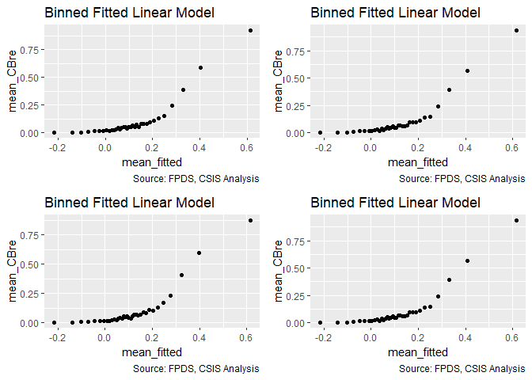

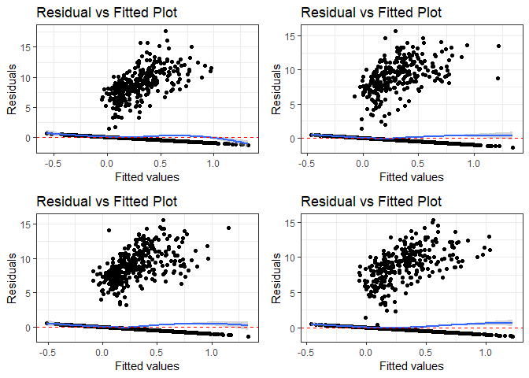

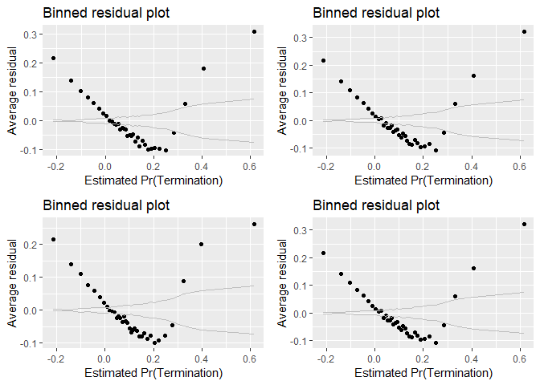

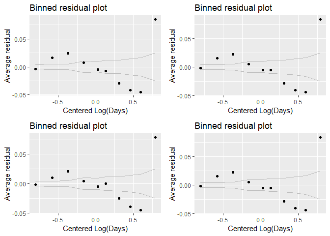

```r
#Compare with cumulative consolidation and competition
summary_residual_compare(ln_CBre_Cons_05B,ln_CBre_Cons_Comp_09A,ln_CBre_Comp_05B,ln_CBre_Cons_Comp_09A,bins=20,skip_vif = TRUE)
```

```r
if(exists("ln_CBre_05A")) rm(ln_CBre_05A)
```